# paVerse: From a Messy HRIS Export to a Standardized Attrition Report

A reference pipeline built on `padm`, `pa.synthetic`, `workforce`, and `attrition`

Published

August 11, 2026

```r
library(pa.synthetic)
library(workforce)
library(attrition)
library(dplyr)
library(gt)
library(ggplot2)
library(scales)

source("standardize.R")
theme_set(theme_minimal(base_size = 11))
```

## Why this exists

Every pharma company runs `admiral` on the same CDISC data model and gets interoperable analysis pipelines for free. Every HR analytics team reinvents headcount, tenure, and turnover logic from scratch — usually with a different, unstated denominator for “turnover rate” every time. This report is a runnable proof that the same trick pharmaverse plays works here: one shared data model (`padm`), pure derivation functions built on it (`workforce`), and standardized metrics on top (`attrition`), all validated against synthetic data with a documented reconciliation invariant.

Nothing in this report is real HR data. `pa.synthetic` generates a seeded, reproducible synthetic organization — including a deliberately messy raw export and a documented, deliberate adverse-impact signal in one job family, so downstream fairness tooling has something real to find later.

## 1. Ingest: a messy vendor export

Real HRIS exports are never `padm`-shaped. `pa.synthetic::pa_synth_raw()` takes a clean event stream and re-renders it the way a Workday extract actually arrives: renamed columns, three different date formats mixed row by row, inconsistent casing on the event reason text, and stray padding whitespace. No information is lost — every quirk is a format problem, not a data-quality problem — but it has to be handled before anything downstream can trust it.

```r
raw <- padm_demo_raw
glimpse_cols <- c("Worker ID", "Effective Date", "Event Reason", "Supervisory Org", "FTE %")
raw[1:8, glimpse_cols] |>
  gt() |>
  tab_header(title = "Raw export (first 8 rows, subset of columns)") |>
  tab_style(style = cell_text(font = "monospace"), locations = cells_body())
```

Raw export (first 8 rows, subset of columns)

| Worker ID | Effective Date | Event Reason | Supervisory Org | FTE % |
| --- | --- | --- | --- | --- |
| P000001 | 43475 | hire | OU0011 | 100% |
| P000001 | 43992 | exit - involuntary | OU0011 | 100% |
| P000002 | 2019-01-16 | HIRE | OU0012 | 100% |
| P000002 | 09/16/2020 | EXIT - VOLUNTARY | OU0012 | 100% |
| P000003 | 01/16/2019 | Hire | OU0009 | 100% |
| P000003 | 05/16/2019 | PAY_CHANGE | OU0009 | 100% |
| P000003 | 06/16/2019 | Promotion | OU0009 | 100% |
| P000003 | 2020-03-16 | Exit - Voluntary | OU0009 | 100% |

Three date formats and three casing styles appear in just the first few rows — that’s the point.

## 2. Standardize to `padm`

`demo/standardize.R` parses the three date formats, normalizes the event-reason text back to the controlled vocabulary in `spec/padm/vocab/event-types.csv`, converts `"100%"` strings to numeric `fte`, and maps vendor column names to `padm` names. This is the one piece of code in this whole pipeline that’s specific to “Workday” as a source system — everything after this line only ever sees `pa_event`.

```r
event <- standardize_workday(raw)

event[1:8, c("person_id", "event_date", "event_type", "event_subtype", "org_unit_id", "fte")] |>
  gt() |>
  tab_header(title = "Standardized pa_event (same 8 rows)")
```

Standardized pa_event (same 8 rows)

| person_id | event_date | event_type | event_subtype | org_unit_id | fte |
| --- | --- | --- | --- | --- | --- |
| P000001 | 2019-01-10 | hire | NA | OU0011 | 1 |
| P000001 | 2020-06-10 | exit | involuntary | OU0011 | 1 |
| P000002 | 2019-01-16 | hire | NA | OU0012 | 1 |
| P000002 | 2020-09-16 | exit | voluntary | OU0012 | 1 |
| P000003 | 2019-01-16 | hire | NA | OU0009 | 1 |
| P000003 | 2019-05-16 | pay_change | NA | OU0009 | 1 |
| P000003 | 2019-06-16 | promotion | NA | OU0009 | 1 |
| P000003 | 2020-03-16 | exit | voluntary | OU0009 | 1 |

## 3. Validate against `padm`

`padm_validate()` checks required tables, required columns at the requested conformance level, the controlled vocabulary, and the two conditional rules in the `pa_event` schema (`event_subtype` required on `exit`; `base_pay_currency` required whenever `base_pay_amount` is present). The org and job catalogs are supplied separately from the events extract, as they would be in a real integration.

```r
tables <- list(
  pa_person = padm_demo_person,
  pa_event = event,
  pa_org_unit = padm_demo_org_unit,
  pa_job = padm_demo_job
)
validation <- padm_validate(tables, level = "extended")
validation
```

```
<padm_validation> requested: extended | achieved: extended | PASS
```

Conformance achieved: **extended**. No failures.

## 4. Derive assignments

`wf_assignments()` folds the event stream into `pa_assignment`: one row per person per uninterrupted assignment interval, SCD-2 style. This is the only place in the pipeline where “who was where, doing what job, reporting to whom, for how long” gets materialized — and it’s a pure function of `pa_event`, so it can always be rebuilt.

```r
assignments <- wf_assignments(event)
cat(sprintf(
  "%s assignment intervals across %s persons (%.1f intervals/person on average)\n",
  format(nrow(assignments), big.mark = ","),
  format(length(unique(assignments$person_id)), big.mark = ","),
  nrow(assignments) / length(unique(assignments$person_id))
))
```

```
1,382 assignment intervals across 600 persons (2.3 intervals/person on average)
```

## 5. Headcount and the reconciliation invariant

`wf_snapshot()` produces a dense person-by-month grid; `wf_reconcile()` checks the one invariant that matters — `opening + hires − exits == closing` — for every period. Because `pa_assignment` and `pa_headcount_snapshot` are both derived from the same `pa_event` stream, this can only fail if the derivation logic itself has a bug, never because two independently-maintained tables drifted apart.

```r
snapshot <- wf_snapshot(assignments, period = "month")
reconcile <- wf_reconcile(snapshot, event, period = "month")

checked <- reconcile$reconciled[!is.na(reconcile$reconciled)]
cat(sprintf("%d / %d monthly periods reconciled exactly\n", sum(checked), length(checked)))
```

```
83 / 83 monthly periods reconciled exactly
```

```r
if (!all(checked)) stop("reconciliation invariant failed")

reconcile |>
  tail(12) |>
  gt() |>
  tab_header(title = "Reconciliation, last 12 months") |>
  fmt_integer(columns = c(opening, hires, exits, expected_closing, closing)) |>
  cols_label(reconciled = "opening + hires − exits == closing")
```

Reconciliation, last 12 months

| period | opening | hires | exits | expected_closing | closing | opening + hires − exits == closing |
| --- | --- | --- | --- | --- | --- | --- |
| 2025-01-01 | 398 | 0 | 3 | 395 | 395 | TRUE |
| 2025-02-01 | 395 | 0 | 10 | 385 | 385 | TRUE |
| 2025-03-01 | 385 | 0 | 2 | 383 | 383 | TRUE |
| 2025-04-01 | 383 | 0 | 3 | 380 | 380 | TRUE |
| 2025-05-01 | 380 | 0 | 3 | 377 | 377 | TRUE |
| 2025-06-01 | 377 | 0 | 8 | 369 | 369 | TRUE |
| 2025-07-01 | 369 | 0 | 2 | 367 | 367 | TRUE |
| 2025-08-01 | 367 | 0 | 10 | 357 | 357 | TRUE |
| 2025-09-01 | 357 | 0 | 1 | 356 | 356 | TRUE |
| 2025-10-01 | 356 | 0 | 2 | 354 | 354 | TRUE |
| 2025-11-01 | 354 | 0 | 5 | 349 | 349 | TRUE |
| 2025-12-01 | 349 | 0 | 3 | 346 | 346 | TRUE |

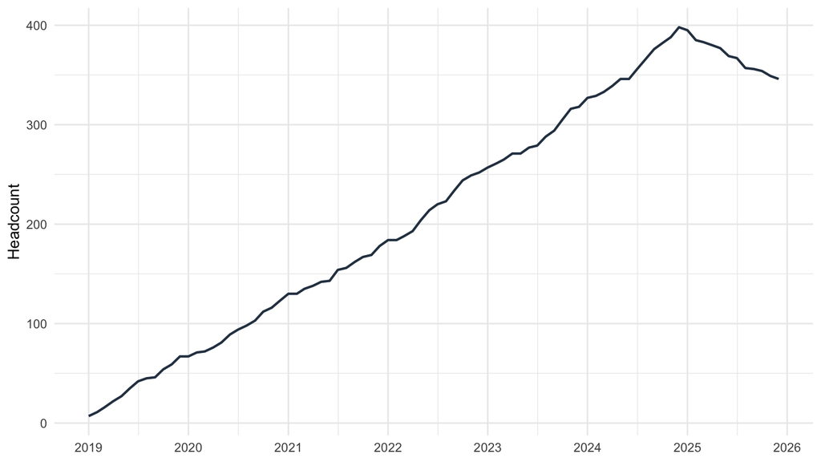

Total headcount by month, derived entirely from pa_event

```r
reconcile |>
  ggplot(aes(period, closing)) +
  geom_line(color = "#2c3e50", linewidth = 0.8) +
  scale_x_date(date_breaks = "1 year", date_labels = "%Y") +
  labs(x = NULL, y = "Headcount")
```

## 6. Turnover rate under three definitions — the punchline

This is the sharpest concrete argument for a shared standard: computed on the **identical** assignments and events, over the **identical** twelve-month window, “turnover rate” produces three different numbers depending on an unstated denominator choice. `padm` makes `exposure` the canonical default (`spec/padm/padm-v0.md` §7) precisely because it is the only one that is mathematically consistent with the event-sourced spine — but `attr_rate()` requires the definition be named explicitly every time, so a reported number is never ambiguous about what it measures.

```r
win_from <- as.Date("2025-01-01")
win_to <- as.Date("2026-01-01")

rates <- bind_rows(lapply(
  c("exposure", "avg_headcount", "beginning_headcount"),
  function(d) attr_rate(assignments, event, win_from, win_to, definition = d)
))

rates |>
  gt() |>
  tab_header(title = "Calendar-year 2025 turnover, three ways") |>
  fmt_number(columns = denominator, decimals = 1) |>
  fmt_percent(columns = rate, decimals = 1) |>
  cols_label(
    definition = "Denominator definition", exits = "Exits",
    denominator = "Denominator", rate = "Turnover rate"
  )
```

Calendar-year 2025 turnover, three ways

| from | to | Denominator definition | Exits | Denominator | Turnover rate |
| --- | --- | --- | --- | --- | --- |
| 2025-01-01 | 2026-01-01 | exposure | 52 | 370.0 | 14.1% |
| 2025-01-01 | 2026-01-01 | avg_headcount | 52 | 372.0 | 14.0% |
| 2025-01-01 | 2026-01-01 | beginning_headcount | 52 | 398.0 | 13.1% |

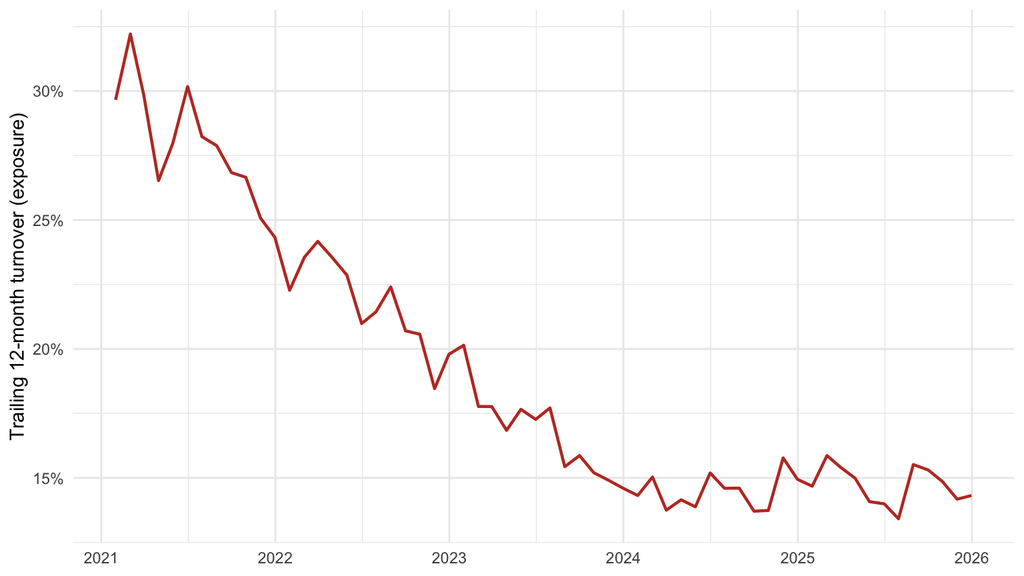

Trailing 12-month exposure-based turnover rate, monthly

```r
period_ends <- seq(as.Date("2021-01-31"), as.Date("2025-12-31"), by = "month")
rolling <- attr_rate_rolling(assignments, event, period_ends, window_months = 12, definition = "exposure")

rolling |>
  ggplot(aes(to, rate)) +
  geom_line(color = "#c0392b", linewidth = 0.8) +
  scale_y_continuous(labels = percent_format(accuracy = 1)) +
  scale_x_date(date_breaks = "1 year", date_labels = "%Y") +
  labs(x = NULL, y = "Trailing 12-month turnover (exposure)")
```

## 7. Retention curves by hire cohort

A single point-in-time rate can’t answer “are recent hires retaining better or worse than people hired three years ago at the same point in their tenure?” A Kaplan-Meier curve, grouped by hire-year cohort, can.

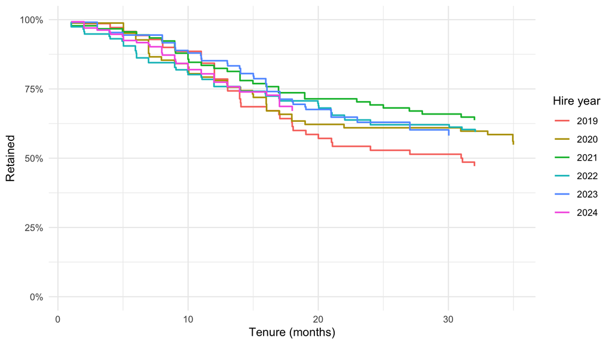

Kaplan-Meier retention by hire-year cohort, censored at 36 months

```r
tenure <- wf_tenure(assignments, as_of = win_to - 1)
curve <- attr_curve(tenure, cohort = "hire_year", max_months = 36)

curve |>
  ggplot(aes(time_months, survival, color = group)) +
  geom_step(linewidth = 0.7) +
  scale_y_continuous(labels = percent_format(accuracy = 1), limits = c(0, 1)) +
  labs(x = "Tenure (months)", y = "Retained", color = "Hire year")
```

## 8. Cohort retention table

```r
attr_cohort(tenure, checkpoints_months = c(3, 6, 12, 24)) |>
  gt(groupname_col = "cohort") |>
  tab_header(title = "Retention by hire-year cohort") |>
  fmt_percent(columns = retention, decimals = 0) |>
  sub_missing(columns = retention, missing_text = "n/a (nobody observable yet)") |>
  cols_label(checkpoint_months = "Tenure checkpoint (months)", n = "Cohort size",
             n_observable = "Observable", retention = "Retained")
```

Retention by hire-year cohort

| Cohort size | Tenure checkpoint (months) | Observable | Retained |
| --- | --- | --- | --- |
| 2019 |  |  |  |
| 70 | 3 | 70 | 99% |
| 70 | 6 | 70 | 96% |
| 70 | 12 | 70 | 84% |
| 70 | 24 | 70 | 54% |
| 2020 |  |  |  |
| 82 | 3 | 82 | 99% |
| 82 | 6 | 82 | 93% |
| 82 | 12 | 82 | 78% |
| 82 | 24 | 82 | 61% |
| 2021 |  |  |  |
| 91 | 3 | 91 | 98% |
| 91 | 6 | 91 | 96% |
| 91 | 12 | 91 | 82% |
| 91 | 24 | 91 | 69% |
| 2022 |  |  |  |
| 116 | 3 | 116 | 95% |
| 116 | 6 | 116 | 89% |
| 116 | 12 | 116 | 76% |
| 116 | 24 | 116 | 64% |
| 2023 |  |  |  |
| 108 | 3 | 108 | 99% |
| 108 | 6 | 108 | 94% |
| 108 | 12 | 108 | 85% |
| 108 | 24 | 108 | 63% |
| 2024 |  |  |  |
| 133 | 3 | 133 | 97% |
| 133 | 6 | 133 | 92% |
| 133 | 12 | 133 | 77% |
| 133 | 24 | 39 | 0% |

## 9. Org-unit breakdown, with small-cell suppression

`spec/padm/padm-v0.md` §5 tags every column with a sensitivity tier so a future `pa.privacy` package can enforce suppression automatically. There’s no such package yet, but the reporting discipline it’s meant to enforce is cheap to apply by hand today: any org unit too small to report on without risking re-identification is suppressed rather than shown.

```r
org_lookup <- unique(padm_demo_org_unit[, c("org_unit_id", "org_unit_name")])
units <- unique(assignments$org_unit_id)

by_unit <- bind_rows(lapply(units, function(u) {
  asn_u <- assignments[assignments$org_unit_id == u, ]
  ev_u <- event[event$org_unit_id == u, ]
  size <- attr_rate(asn_u, ev_u, win_from, win_to, "avg_headcount")$denominator
  exp <- attr_rate(asn_u, ev_u, win_from, win_to, "exposure")
  data.frame(org_unit_id = u, avg_headcount = size, exits = exp$exits, rate = exp$rate)
}))

SUPPRESSION_THRESHOLD <- 11 # common small-cell suppression convention

by_unit |>
  left_join(org_lookup, by = "org_unit_id") |>
  mutate(
    suppressed = avg_headcount < SUPPRESSION_THRESHOLD,
    exits = ifelse(suppressed, NA_integer_, exits),
    rate = ifelse(suppressed, NA_real_, rate)
  ) |>
  arrange(desc(avg_headcount)) |>
  select(org_unit_name, avg_headcount, exits, rate) |>
  gt() |>
  tab_header(title = "2025 turnover (exposure) by org unit",
             subtitle = sprintf("Units with average headcount below %d are suppressed", SUPPRESSION_THRESHOLD)) |>
  fmt_number(columns = avg_headcount, decimals = 1) |>
  fmt_percent(columns = rate, decimals = 1) |>
  sub_missing(columns = c(exits, rate), missing_text = "suppressed") |>
  cols_label(org_unit_name = "Org unit", avg_headcount = "Avg. headcount",
             exits = "Exits", rate = "Turnover rate")
```

2025 turnover (exposure) by org unit

Units with average headcount below 11 are suppressed

| Org unit | Avg. headcount | Exits | Turnover rate |
| --- | --- | --- | --- |
| Engineering Team 10 | 67.0 | 7 | 10.5% |
| Engineering Team 14 | 63.5 | 7 | 10.7% |
| Marketing Team 12 | 59.5 | 6 | 10.2% |
| People Team 15 | 53.5 | 9 | 17.1% |
| Marketing Team 11 | 47.0 | 5 | 10.9% |
| Finance Team 13 | 44.5 | 9 | 20.3% |
| Sales Team 9 | 37.0 | 9 | 24.6% |

## Reproducibility

Everything above is generated from `pa.synthetic`’s cached demo dataset (`seed = 42`, 600-person hiring cohort, 2019–2025). Re-running `quarto render demo/attrition-report.qmd` from a clean checkout reproduces this document exactly. `demo/run.R` runs the same pipeline headless as a CI smoke test.

```
 package      * version    date (UTC) lib source
 attrition    * 0.0.0.9000 2026-08-11 [1] local
 pa.synthetic * 0.0.0.9000 2026-08-11 [1] local
 workforce    * 0.0.0.9000 2026-08-11 [1] local

 [1] /Users/dmeza/Library/R/arm64/4.5/library
 [2] /Library/Frameworks/R.framework/Versions/4.5-arm64/Resources/library
 * ── Packages attached to the search path.
```